# Two One-Sided Test (TOST)

Alison Telford

2023-01-10

# Introduction

The Two One-Sided Test or TOST essentially does what it says on the tin. It is basically the same as performing two one-sided t-tests or a non-parametric equivalent. It’s purpose is to statistically test whether two paired or non-paired samples can be deemed equivalent or not.

# Theory

## Non-Paired Samples

Consider two independent samples of $n$ observations from some population, namely
$$x_1, \ldots, x_n \\
y_1, \ldots, y_n$$

We want to test to see whether the mean of sample 1 is equivalent to the mean of sample 2. Crudely, we could construct the hypothesis test as follows;
$$\textrm{H}_0: \mu_x \neq \mu_y \\
\textrm{vs} \\
\textrm{H}_1: \mu_x = \mu_y$$
where the null hypothesis is that the means are different and thus rejecting the null hypothesis would conclude equivalence. However, in this setup, there are infinitely many null distributions which would make testing this hypothesis impossible.

Instead, consider formulating two one-sided hypothesis tests for some threshold $\delta$ as follows;

1. $$\textrm{H}_0: \mu_x - \mu_y \geq \delta \\
   \textrm{vs} \\
   \textrm{H}_1: \mu_x - \mu_y < \delta$$
2. $$\textrm{H}_0: \mu_x - \mu_y \leq -\delta \\
   \textrm{vs} \\
   \textrm{H}_1: \mu_x - \mu_y > -\delta$$

Then a rejection of both null hypotheses would conclude
$$-\delta < \mu_x - \mu_y < \delta$$
and for small enough $\delta$ we can therefore conclude equivalence.

To test the hypotheses two one-sided two sample hypothesis tests can be performed. Note that to conclude equivalence at 5% significance threshold both p-values would need to be less than 0.025 using the Bonferroni correction.

## Paired Samples

Consider two dependent samples of $n$ observations from some population, namely
$$x_1, \ldots, x_n \\
y_1, \ldots, y_n$$
and calculate the difference between each pair such that
$$x_i - y_i = d_i ~~~~~~~~~ i = 1,\ldots, n.$$

Then a rejection of both null hypotheses would conclude
$$-\delta < \mu_d < \delta$$
and for small enough $\delta$ we can therefore conclude equivalence.

To test the hypotheses two one-sided one sample hypothesis tests can be performed. Note that to conclude equivalence at 5% significance threshold both p-values would need to be less than 0.025 using the Bonferroni correction.

# Power Calculations

## Theory

### Non-Paired Samples

The power of a hypothesis test is calculated as
$$\textrm{Pr}\{\textrm{Reject H}_0 | \textrm{H}_0 \textrm{ is false}\}.$$

If we are performing two one-sided two-sample $t$-tests, this can be equated to
$$\textrm{Pr}\{t_1 < t_{\alpha, 2n-2} \cap t_2 > t_{1-\alpha, 2n-2}|
-\delta < \mu_x - \mu_y < \delta\}$$
where
$$t_1 = \frac{\bar{x} - \bar{y} - \delta}{\frac{\hat{s}}{\sqrt{n/2}}}, \\
t_2 = \frac{\bar{x} - \bar{y} + \delta}{\frac{\hat{s}}{\sqrt{n/2}}},$$
$$\hat{s}^2 = \frac{(n-1)s_x^2 + (n-1)s_y^2}{2n-2},$$
and $t_{\alpha, 2n-2}$ represents the $\alpha$th quantile of the $t$ distribution with $2n-2$ degrees of freedom.

Under the alternative hypothesis, we assume that $\mu_x - \mu_y = 0$, thus
$$t_1 = \frac{-\delta}{\frac{\hat{s}}{\sqrt{n/2}}}, \\
t_2 = \frac{\delta}{\frac{\hat{s}}{\sqrt{n/2}}}.$$
It can therefore be concluded that
$$t_1 \sim N\left(\frac{-\delta}{\sigma/\sqrt{n/2}}, 1\right) \\
t_2 \sim N\left(\frac{\delta}{\sigma/\sqrt{n/2}}, 1\right).$$

Let $mt_1$ and $mt_2$ be the means of $t_1$ and $t_2$ respectively and $T = t_1 - mt_1$. Also note that $t_1 = t_2 - 2mt_2$ and $mt_1 = -mt_2$. Thus,
$$\begin{align}
&T = t_1 - mt_1 \\
\implies&T = t_2 - 2mt_2 - mt_1 \\
\implies&T = t_2 - 2mt_2 + mt_2 \\
\implies&T = t_2 - mt_2.
\end{align}$$

If $t_{1-\alpha, 2n-2} = t_c$, the $(1-\alpha)\%$ critical value of the $t$-distribution, then $t_{\alpha, 2n-2} = -t_c$ due to symmetry. Thus,
$$\begin{align}
&\textrm{Pr}\{t_1 < t_{\alpha, 2n-2} \cap t_2 > t_{1-\alpha,
2n-2}\} \\
&=\textrm{Pr}\{T < -mt_1 - t_c \cap T > -mt_2 + t_c\} \\
&=\textrm{Pr}\{T < mt_2 - t_c \cap T > mt_1 + t_c\} \\
&=\textrm{Pr}\{T < mt_2 - t_c\} - \textrm{Pr}\{T < mt_1 +
t_c\}.
\end{align}$$
As T follows a standard normal distribution, we can calculate this probability using the non-central $t$ distribution.

### Paired Samples

The power of a hypothesis test is calculated as
$$\textrm{Pr}\{\textrm{Reject H}_0 | \textrm{H}_0 \textrm{ is false}\}.$$

If we are performing two one-sided one-sample $t$-tests, this can be equated to
$$\textrm{Pr}\{t_1 < t_{\alpha, n-1} \cap t_2 > t_{1-\alpha, n-1}|
-\delta < \mu_d < \delta\}$$
where
$$t_1 = \frac{\bar{d} - \delta}{\frac{s_d}{\sqrt{n}}}, \\
t_2 = \frac{\bar{d} + \delta}{\frac{s_d}{\sqrt{n}}},$$
and $t_{\alpha, n-1}$ represents the $\alpha$th quantile of the $t$ distribution with $n-1$ degrees of freedom.

Under the alternative hypothesis, we assume that $\mu_d = 0$, thus
$$t_1 = \frac{-\delta}{\frac{s_d}{\sqrt{n}}}, \\
t_2 = \frac{\delta}{\frac{s_d}{\sqrt{n}}}.$$
It can therefore be concluded that
$$t_1 \sim N\left(\frac{-\delta}{\sigma/\sqrt{n}}, 1\right) \\
t_2 \sim N\left(\frac{\delta}{\sigma/\sqrt{n}}, 1\right).$$

Let $mt_1$ and $mt_2$ be the means of $t_1$ and $t_2$ respectively and $T = t_1 - mt_1$. Also note that $t_1 = t_2 - 2mt_2$ and $mt_1 = -mt_2$. Thus,
$$\begin{align}
&T = t_1 - mt_1 \\
\implies&T = t_2 - 2mt_2 - mt_1 \\
\implies&T = t_2 - 2mt_2 + mt_2 \\
\implies&T = t_2 - mt_2.
\end{align}$$

If $t_{1-\alpha, n-1} = t_c$, the $(1-\alpha)\%$ critical value of the $t$-distribution, then $t_{\alpha, n-1} = -t_c$ due to symmetry. Thus,
$$\begin{align}
&\textrm{Pr}\{t_1 < t_{\alpha, n-1} \cap t_2 > t_{1-\alpha,
n-1}\} \\
&=\textrm{Pr}\{T < -mt_1 - t_c \cap T > -mt_2 + t_c\} \\
&=\textrm{Pr}\{T < mt_2 - t_c \cap T > mt_1 + t_c\} \\
&=\textrm{Pr}\{T < mt_2 - t_c\} - \textrm{Pr}\{T < mt_1 +
t_c\}.
\end{align}$$
As T follows a standard normal distribution, we can calculate this probability using the non-central $t$ distribution.

# Example

```r
#Define an Acceptance Criteria a-priori
AC = 0.5
#Set the sample size
n = 100
#Simulate two sets of data from standard normal distribution
set.seed(1)
x = rnorm(n)
set.seed(2)
y = rnorm(n)
#Create a data frame with the two simulated data sets
df = data.frame(x, y)
#Calculate the differences and the means and append to df
df = df %>%
  mutate(diffs = x - y,
         means = (x+y)/2)
#Calculate the bias
Bias = mean(df$diffs)
#Calculate the TOST p-values.
pvalue_1 = t.test(df$diffs - AC, alternative = "less")$p.val
pvalue_2 = t.test(df$diffs + AC, alternative = "greater")$p.val
print(pvalue_1)
```

```
## [1] 0.012018
```

```r
print(pvalue_2)
```

```
## [1] 4.78593e-05
```

The maximum p-value is therefore 0.012018 and because both are less than 0.025 we can conclude equivalence at 5% level.

# Graphically Visualising the TOST

It is possible for paired data, without performing any statistical tests, to visually assess whether the TOST will conclude equivalence.

The TOST procedure works by not only considering the value of the bias itself but also it’s standard error or uncertainty. Thus if the 95% confidence interval for the bias lies within $[-\delta, \delta]$, equivalence is concluded at the 5% significance level.

It is then easy to assess this using a Bland-Altman plot, e.g. plotting the mean of each paired observation against the difference of each paired observation.

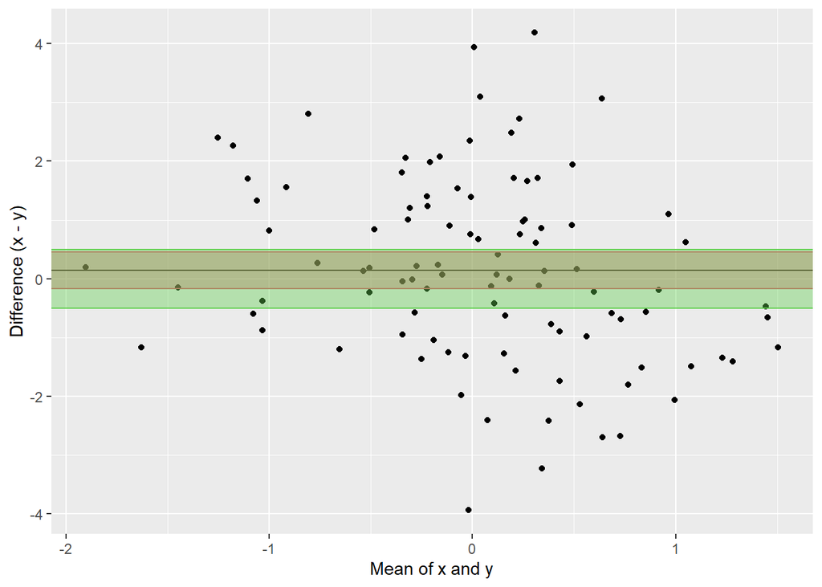

```r
#Calculate the 95% confidence interval for the bias
bias_lower = Bias - qt(0.975, df = n-1)*sd(df$diffs)/sqrt(n)
bias_upper = Bias + qt(0.975, df = n-1)*sd(df$diffs)/sqrt(n)
ggplot(df, aes(x = means, y = diffs)) +
  geom_point() +
  geom_hline(yintercept = Bias) +
  geom_hline(yintercept = bias_lower, col = 2) +
  geom_hline(yintercept = bias_upper, col = 2) +
  geom_hline(yintercept = -AC, col = 3) +
  geom_hline(yintercept = AC, col = 3) +
  annotate("rect", xmin = -Inf, xmax = Inf,
           ymin = bias_lower, ymax = bias_upper,
           fill = 2, alpha = 0.4) +
  annotate("rect", xmin = -Inf, xmax = Inf,
           ymin = -AC, ymax = AC,
           fill = 3, alpha = 0.4) +
  labs(x = "Mean of x and y",
       y = "Difference (x - y)")
```

The 95% confidence interval for the bias is entirely within $[-\delta, \delta]$, thus we know - without needing to perform a hypothesis test - that the TOST test will pass, and we can conclude equivalence at 5% level.

# Calculating Delta

One can calculate an appropriate value for $\delta$ by calculating the standard error of the bias using previous data and adjusting it based on the sample size of the new data. Thus an expected confidence interval for the bias can be calculated if the variability was the same as before.

If the variability of the previous data was accepted to be reasonable, then we could use the expected confidence interval of the bias adjusting for bias = 0 to be the $[-\delta, \delta]$.

# R Code

The following function can be applied in R to calculate the power of the TOST. Note that this function can also be inverted to calculate the sample size to achieve a required power.

```r
TOST_power = function(N, std, delta, alpha, type = 'one.sample'){
  if (type == 'one.sample'){
    se = std/sqrt(N)
    mt1 = -delta/se
    mt2 = delta/se
    tc = qt(1 - alpha, df = N-1, lower.tail = T)
    Power = pt(-tc, df = N-1, ncp = -mt2) - pt(tc, df = N-1, ncp = -mt1)
  }else{
    if (type == 'two.sample'){
      se = std*sqrt(2)/sqrt(N)
      mt1 = -delta/se
      mt2 = delta/se
      tc = qt(1 - alpha, df = 2*N-2, lower.tail = T)
      Power = pt(-tc, df = 2*N-2, ncp = -mt2) - pt(tc, df = 2*N-2, ncp = -mt1)
    }
  }
  Power[Power<0] = 0
  Power
}
```